# Lab 05 - Data Wrangling

# Learning goals

- Use the `merge()` function to join two datasets.
- Deal with missings and impute data.
- Identify relevant observations using `quantile()`.
- Practice your GitHub skills.

# Lab description

For this lab we will be dealing with the meteorological dataset `met`. In this case, we will use `data.table` to answer some questions regarding the `met` dataset, while at the same time practice your Git+GitHub skills for this project.

This markdown document should be rendered using `github_document` document.

# Part 1: Setup a Git project and the GitHub repository

1. Go to wherever you are planning to store the data on your computer, and create a folder for this project
2. In that folder, save [this template](https://github.com/JSC370/JSC370-2025/blob/main/labs/lab05/lab05-wrangling-gam.Rmd) as “README.Rmd”. This will be the markdown file where all the magic will happen.
3. Go to your GitHub account and create a new repository of the same name that your local folder has, e.g., “JSC370-labs”.
4. Initialize the Git project, add the “README.Rmd” file, and make your first commit.
5. Add the repo you just created on GitHub.com to the list of remotes, and push your commit to origin while setting the upstream.

Most of the steps can be done using command line:

```bash
# Step 1
cd ~/Documents
mkdir JSC370-labs
cd JSC370-labs

# Step 2
wget https://raw.githubusercontent.com/JSC370/jsc370-2023/main/labs/lab05/lab05-wrangling-gam.Rmd
mv lab05-wrangling-gam.Rmd README.Rmd
# if wget is not available,
curl https://raw.githubusercontent.com/JSC370/jsc370-2023/main/labs/lab05/lab05-wrangling-gam.Rmd --output README.Rmd

# Step 3
# Happens on github

# Step 4
git init
git add README.Rmd
git commit -m "First commit"

# Step 5
git remote add origin git@github.com:[username]/JSC370-labs
git push -u origin master
```

You can also complete the steps in R (replace with your paths/username when needed)

```r
# Step 1
setwd("~/Documents")
dir.create("JSC370-labs")
setwd("JSC370-labs")

# Step 2
download.file(
  "https://raw.githubusercontent.com/JSC370/jsc370-2023/main/labs/lab05/lab05-wrangling-gam.Rmd",
  destfile = "README.Rmd"
  )

# Step 3: Happens on Github

# Step 4
system("git init && git add README.Rmd")
system('git commit -m "First commit"')

# Step 5
system("git remote add origin git@github.com:[username]/JSC370-labs")
system("git push -u origin master")
```

Once you are done setting up the project, you can now start working with the MET data.

## Setup in R

1. Load the `data.table` (and the `dtplyr` and `dplyr` packages).

```r
library(data.table)
library(dtplyr)
library(dplyr)
library(leaflet)
library(mgcv)
```

```r
library(ggplot2)
```

2. Load the met data from https://raw.githubusercontent.com/JSC370/JSC370-2024/main/data/met_all_2023.gz, and also the station data. For the latter, you can use the code we used during lecture to pre-process the stations data:

```r
# Download the data
stations <- fread("ftp://ftp.ncdc.noaa.gov/pub/data/noaa/isd-history.csv")
stations[, USAF := as.integer(USAF)]
# Dealing with NAs and 999999
stations[, USAF   := fifelse(USAF == 999999, NA_integer_, USAF)]
stations[, CTRY   := fifelse(CTRY == "", NA_character_, CTRY)]
stations[, STATE  := fifelse(STATE == "", NA_character_, STATE)]

# Selecting the three relevant columns, and keeping unique records
stations <- unique(stations[, list(USAF, CTRY, STATE)])

# Dropping NAs
stations <- stations[!is.na(USAF)]

# Removing duplicates
stations[, n := 1:.N, by = .(USAF)]
stations <- stations[n == 1,][, n := NULL]

# Read in the met data
met_dt <- fread("https://github.com/JSC370/JSC370-2025/raw/refs/heads/main/data/met/met_all.gz")
```

3. Merge the data as we did during the lecture. Use the `merge()` code and you can also try the tidy way with `left_join()`

```r
met_dt <- merge(
    # Data
    x     = met_dt,
    y     = stations,
    # List of variables to match
    by.x  = "USAFID",
    by.y  = "USAF",
    # Which obs to keep?
    all.x = TRUE,
    all.y = FALSE
)

head(met_dt[, list(USAFID, WBAN, STATE)])
```

```
##    USAFID  WBAN STATE
## 1: 690150 93121    CA
## 2: 690150 93121    CA
## 3: 690150 93121    CA
## 4: 690150 93121    CA
## 5: 690150 93121    CA
## 6: 690150 93121    CA
```

## Question 1: Representative station for the US

Across all weather stations, what stations have the median values of temperature, wind speed, and atmospheric pressure? Using the `quantile()` function, identify these three stations. Do they coincide?

```r
medians <- met_dt[, .(
    median_temp = quantile(temp, 0.5, na.rm = TRUE),
    median_wind = quantile(wind.sp, 0.5, na.rm = TRUE),
    median_atm  = quantile(atm.press, 0.5, na.rm = TRUE)
)]

met_dt[(temp == medians$median_temp) & (wind.sp == medians$median_wind) & (atm.press == medians$median_atm)][, USAFID] # there appears to be only 1 station that meets all criteria
```

```
## [1] 722246
```

Knit the document, commit your changes, and save it on GitHub. Don’t forget to add `README.md` to the tree, the first time you render it.

## Question 2: Representative station per state

Just like the previous question, you are asked to identify what is the most representative, the median, station per state. This time, instead of looking at one variable at a time, look at the euclidean distance. If multiple stations show in the median, select the one located at the lowest latitude.

```r
mydist <- function(x, y, z) sqrt(x^2 + y^2 + z^2)

met_dt[, distance := mydist(temp - medians$median_temp, wind.sp - medians$median_wind, atm.press - medians$median_atm)]

representative_stations <- met_dt[
    , .SD[order(distance, lat)][1], by = STATE
]

representative_stations[, list(STATE, USAFID)]
```

```
##     STATE USAFID
##  1:    CA 722975
##  2:    TX 722446
##  3:    MI 726355
##  4:    SC 723117
##  5:    IL 724338
##  6:    MO 723290
##  7:    AR 723407
##  8:    OR 725975
##  9:    WA 720254
## 10:    GA 722270
## 11:    MN 726584
## 12:    AL 722269
## 13:    IN 724380
## 14:    NC 723066
```

[output cut: 35 more lines]

Knit the doc and save it on GitHub.

## Question 3: In the middle?

For each state, identify what is the station that is closest to the mid-point of the state. Combining these with the stations you identified in the previous question, use `leaflet()` to visualize all ~100 points in the same figure, applying different colors for those identified in this question.

```r
medians_by_state <- met_dt[, .(
    median_temp = quantile(temp, 0.5, na.rm = TRUE),
    median_wind = quantile(wind.sp, 0.5, na.rm = TRUE),
    median_atm  = quantile(atm.press, 0.5, na.rm = TRUE)
), by = STATE]

met_dt <- merge(
    # Data
    x     = met_dt,
    y     = medians_by_state,
    # List of variables to match
    by.x  = "STATE",
    by.y  = "STATE",
    # Which obs to keep?
    all.x = TRUE,
    all.y = FALSE
)

met_dt[, statewise_distance := mydist(temp - median_temp, wind.sp - median_wind, atm.press - median_atm)]

statewise_representative_stations <- met_dt[
    , .SD[order(statewise_distance, lat)[1]], by = STATE
]

statewise_representative_stations[, list(STATE, USAFID)]
```

```
##     STATE USAFID
##  1:    AL 722265
##  2:    AR 723419
##  3:    AZ 722730
##  4:    CA 722903
##  5:    CO 724665
##  6:    CT 725027
##  7:    DE 724180
##  8:    FL 722210
##  9:    GA 722175
## 10:    IA 725470
## 11:    ID 726810
## 12:    IL 725430
## 13:    IN 724320
## 14:    KS 724468
```

[output cut: 35 more lines]

```r
# Plotting the stations
leaflet() |>
    addProviderTiles('CartoDB.Positron') |>
    addCircleMarkers(
        data = statewise_representative_stations,
        lng = ~lon,
        lat = ~lat,
        radius = 5,
        color = "blue",
        popup = ~USAFID
    ) |>
    addCircleMarkers(
        data = representative_stations,
        lng = ~lon,
        lat = ~lat,
        radius = 5,
        color = "red",
        popup = ~USAFID
    )
```

[interactive chart not shown]

Knit the doc and save it on GitHub.

## Question 4: Means of means

Using the `quantile()` function, generate a summary table that shows the number of states included, average temperature, wind-speed, and atmospheric pressure by the variable “average temperature level,” which you’ll need to create.

Start by computing the states’ average temperature. Use that measurement to classify them according to the following criteria:

- low: temp < 20
- Mid: temp >= 20 and temp < 25
- High: temp >= 25

```r
state_avg_temp <- met_dt[, .(avg_temp = mean(temp, na.rm = TRUE)), by = STATE]
state_avg_temp[, temp_level := fifelse(avg_temp < 20, "low",
                                       fifelse(avg_temp < 25, "mid", "high"))]
head(state_avg_temp)
```

```
##    STATE avg_temp temp_level
## 1:    AL 26.19799       high
## 2:    AR 26.20697       high
## 3:    AZ 28.80596       high
## 4:    CA 22.36199        mid
## 5:    CO 19.54725        low
## 6:    CT 22.25797        mid
```

Once you are done with that, you can compute the following:

- Number of entries (records),
- Number of NA entries,
- Number of stations,
- Number of states included, and
- Mean temperature, wind-speed, and atmospheric pressure.

All by the levels described before.

```r
met_dt <- merge(met_dt, state_avg_temp[, .(STATE, temp_level)], by = "STATE")

summary_stats <- met_dt[, .(
    num_entries = .N,
    num_na_entries = sum(is.na(temp) | is.na(wind.sp) | is.na(atm.press)),
    num_stations = uniqueN(USAFID),
    num_states = uniqueN(STATE),
    mean_temp = mean(temp, na.rm = TRUE),
    mean_wind_sp = mean(wind.sp, na.rm = TRUE),
    mean_atm_press = mean(atm.press, na.rm = TRUE)
), by = temp_level]

summary_stats
```

```
##    temp_level num_entries num_na_entries num_stations num_states mean_temp
## 1:       high      811126         575696          555         12  27.75066
## 2:        mid     1135423         759000          781         25  22.39909
## 3:        low      430794         338632          259         11  18.96446
##    mean_wind_sp mean_atm_press
## 1:     2.514644       1013.738
## 2:     2.352712       1014.383
## 3:     2.637410       1014.366
```

Knit the document, commit your changes, and push them to GitHub.

## Question 5: Advanced Regression

Let’s practice running regression models with smooth functions on X. We need the `mgcv` package and `gam()` function to do this.

- using your data with the median values per station, examine the association between median temperature (y) and median wind speed (x). Create a scatterplot of the two variables using ggplot2. Add both a linear regression line and a smooth line.
- fit both a linear model and a spline model (use `gam()` with a cubic regression spline on wind speed). Summarize and plot the results from the models and interpret which model is the best fit and why.

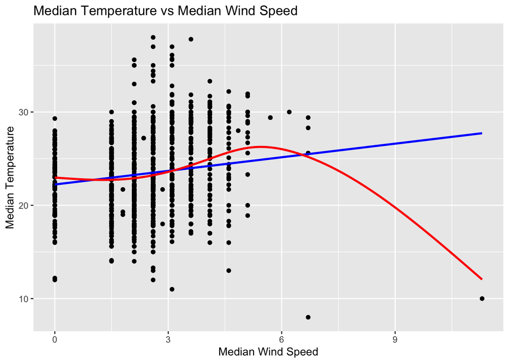

```r
# Compute median values per station
median_values <- met_dt[, .(
    median_temp = median(temp, na.rm = TRUE),
    median_wind_sp = median(wind.sp, na.rm = TRUE)
), by = USAFID]

ggplot(median_values, aes(x = median_wind_sp, y = median_temp)) +
    geom_point() +
    geom_smooth(method = "lm", se = FALSE, color = "blue") +
    geom_smooth(method = "gam", formula = y ~ s(x, bs = "cs"), se = FALSE, color = "red") +
    labs(title = "Median Temperature vs Median Wind Speed",
         x = "Median Wind Speed",
         y = "Median Temperature")
```

```r
lm_model <- lm(median_temp ~ median_wind_sp, data = median_values)
summary(lm_model)
```

```
##
## Call:
## lm(formula = median_temp ~ median_wind_sp, data = median_values)
##
## Residuals:
##      Min       1Q   Median       3Q      Max
## -17.7243  -2.6518  -0.2309   2.7691  14.5052
##
## Coefficients:
##                Estimate Std. Error t value Pr(>|t|)
## (Intercept)    22.23088    0.21779  102.08  < 2e-16 ***
## median_wind_sp  0.48614    0.08212    5.92 3.94e-09 ***
## ---
## Signif. codes:  0 '***' 0.001 '**' 0.01 '*' 0.05 '.' 0.1 ' ' 1
##
## Residual standard error: 3.849 on 1577 degrees of freedom
##   (16 observations deleted due to missingness)
## Multiple R-squared:  0.02174,    Adjusted R-squared:  0.02112
## F-statistic: 35.05 on 1 and 1577 DF,  p-value: 3.941e-09
```

```r
gam_model <- gam(median_temp ~ s(median_wind_sp, bs = "cs"), data = median_values)
summary(gam_model)
```

```
##
## Family: gaussian
## Link function: identity
##
## Formula:
## median_temp ~ s(median_wind_sp, bs = "cs")
##
## Parametric coefficients:
##             Estimate Std. Error t value Pr(>|t|)
## (Intercept) 23.38566    0.09549   244.9   <2e-16 ***
## ---
## Signif. codes:  0 '***' 0.001 '**' 0.01 '*' 0.05 '.' 0.1 ' ' 1
##
## Approximate significance of smooth terms:
##                     edf Ref.df     F p-value
## s(median_wind_sp) 4.808      9 8.961  <2e-16 ***
## ---
## Signif. codes:  0 '***' 0.001 '**' 0.01 '*' 0.05 '.' 0.1 ' ' 1
##
## R-sq.(adj) =  0.0486   Deviance explained = 5.15%
## GCV = 14.451  Scale est. = 14.398    n = 1579
```

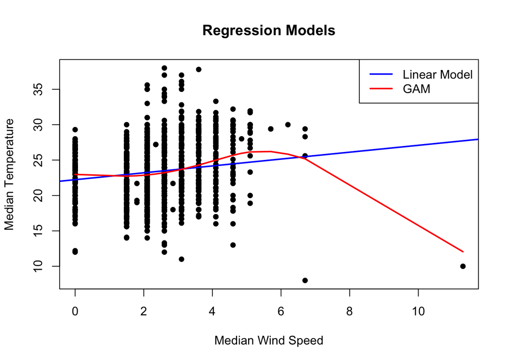

```r
plot(median_values$median_wind_sp, median_values$median_temp, pch = 16,
     xlab = "Median Wind Speed", ylab = "Median Temperature",
     main = "Regression Models")
abline(lm_model, col = "blue", lwd = 2)  # Linear model line
lines(sort(median_values$median_wind_sp),
      predict(gam_model, newdata = data.frame(median_wind_sp = sort(median_values$median_wind_sp))),
      col = "red", lwd = 2)  # GAM model line
legend("topright", legend = c("Linear Model", "GAM"), col = c("blue", "red"), lwd = 2)
```

We can see from the summary statistics that the GAM model has a better fit. In addition, we can see that the smooth term in the GAM model is significant, indicating it is better.